# Week 3 Peer Review

Following the directions on the Coursera assignment page, you will make four original visualizations. Note that the data for the CCES and CEL data are imported in code in the R Markdown file.

### Put your name here:

Lai Chi Long

## Exercise 1

Explain what you are visualizing here:

**scatter plot**

*what to plot:*

Bill passing and bill become law over the years between the two parties.

*observation*

From the graph below the no. of bill passing and became law have a linear relationship. The democrats are more active in having more bills being passed and bills became law, this is shown by the outlines in this scatter plot.

However from question 3 the line plot, democrats have the marjority more times than the republicans, and could have advantages to have more bills passing and become law, and the republicans had less bills to pass and became law.

’’’ Put your figure here:

```
## # A tibble: 6 × 3
##   all_pass all_law Party
##      <dbl>   <dbl> <chr>
## 1        0       0 Republican
## 2        1       1 Democrat
## 3        2       1 Democrat
## 4        0       0 Democrat
## 5        2       1 Democrat
## 6        0       0 Democrat
```

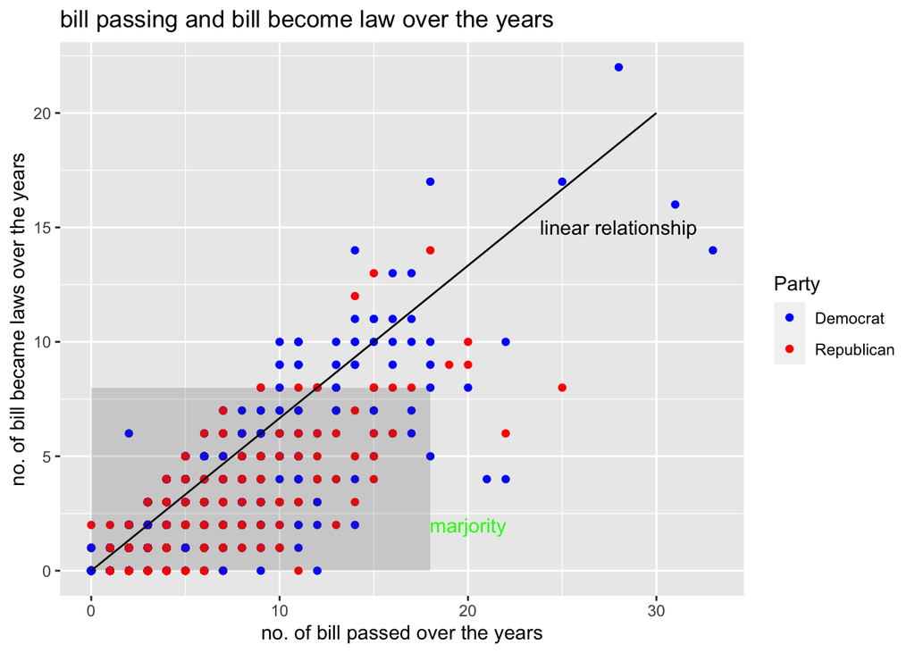

## Exercise 2

Explain what you are visualizing here:

**distribution figure (box plot, histogram, or density plot)**

**density plot**

*what to plot:*

Volden and Wiseman’s legislative effective score (LES) over the years

*observation*

Put your figure here:

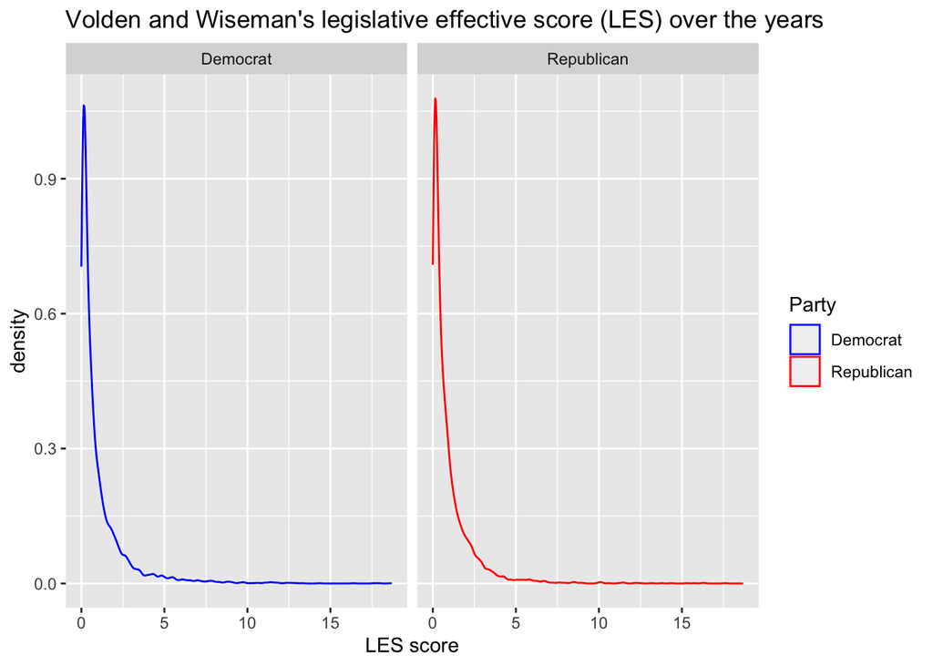

## Exercise 3

Explain what you are visualizing here:

**line plot**

*what to plot:*

Time series of the evolution and changes among the no. of members in congress via out the year.

*observation*

Put your figure here:

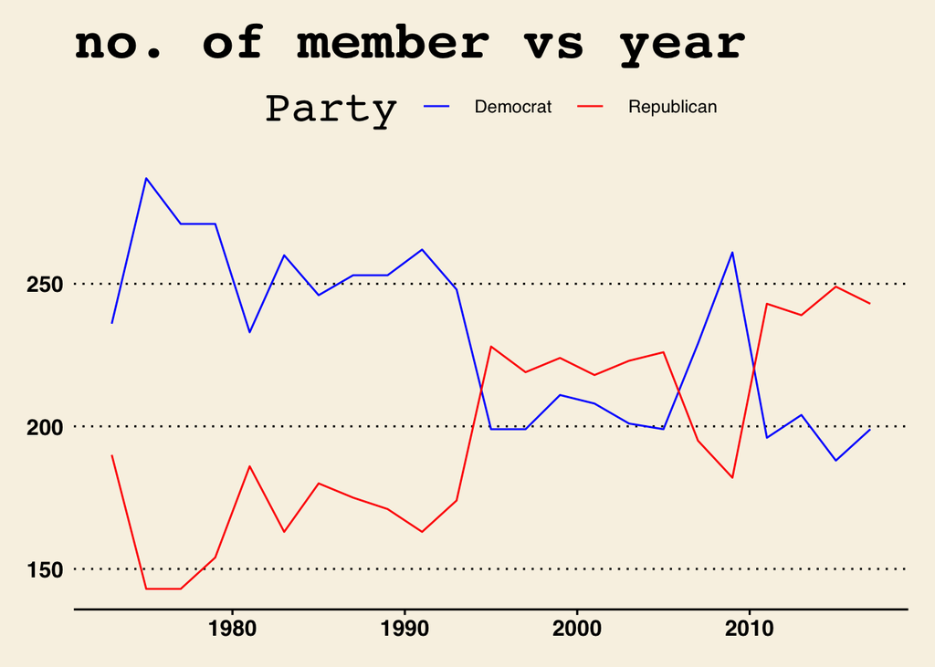

## Exercise 4

Explain what you are visualizing here:

**bar plot**

*what to plot:*

Education level distribution between different regions.

*observation*

Put your figure here:

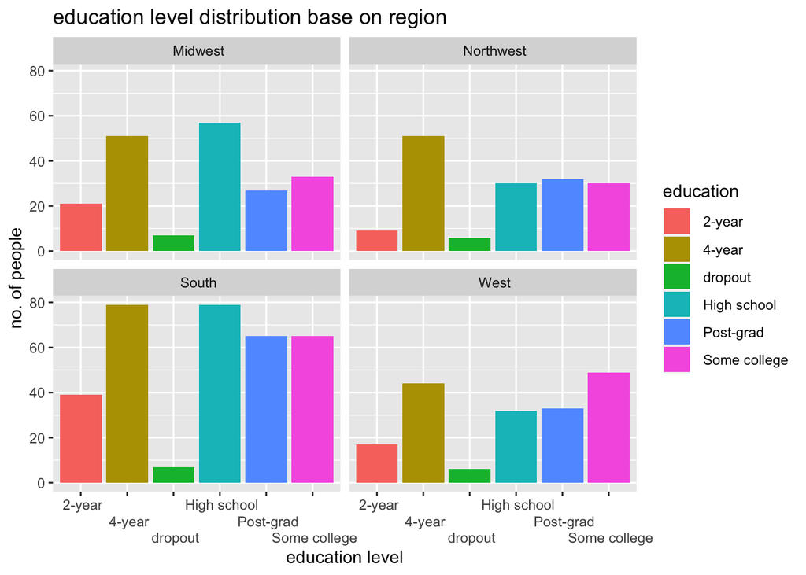